```python
import numpy as np
import pandas as pd
import matplotlib.pyplot as plt
%matplotlib inline
import seaborn as sns
from collections import Counter
from sklearn.ensemble import RandomForestRegressor
from sklearn.metrics import r2_score, mean_squared_error, median_absolute_error
from sklearn.model_selection import train_test_split
from sklearn.metrics import r2_score
```

# 1. Business Questions:

These are the questions that I want to answer during this project on AirBNB Data

- How does pricing by season and what is the high season in Berlin?
- How does pricing by neighborhood and what is the most expensive place in Berlin?
- Is it possile to make an accurate predictive model for listing price based on machine leraning?

# 2. DATA UNDERSTANDING

### 2.1 Data gathering.

```python
# Data gathering
# Import data into dataframes
calendar = pd.read_csv("./Berlin_data/calendar.csv")
listings = pd.read_csv("./Berlin_data/listings.csv")
reviews = pd.read_csv("./Berlin_data/reviews.csv")
```

### 2.2 Assessing Data

```python
def features_categorical(df,name):
    '''
    The function will find Percentage of Unique values per each categorical column for data set
    '''
    print("List of Categorical for", name ," dataset :\n")
    percent_uniquevaluesper_column = df[list(df.select_dtypes(include=['object']))].nunique()/len(df) * 100
    percent_uniquevaluesper_column.sort_values(ascending=False).plot(kind="bar",figsize=(20,5))
    plt.title("Percentage of Unique values per each column")
    plt.xlabel('Column Name')
    plt.ylabel('Percentage of Unique values')
    plt.show()
    for x in list(df.select_dtypes(include=['object'])):
        if (df[x].nunique() < 10):
            uniquelist = df[x].unique()
            print("- ",x,":", df[x].nunique()," and list of unique values that are less than 10 : ", uniquelist)
```

```python
# Data assessing
def assesing_df(df):
    '''
    The function will assess dataset as following:
    - Number of rows and columns
    - Distribution of percentage of missing values.
    - Applying decribe function for dataset.
    - Percentage of missing values per each colum.
    - List of columns have more than 20% Missing Values.
    - Percentage of Missing Values in Rows
    - features_categorical
    '''

    name =[x for x in globals() if globals()[x] is df][0]
    # Print rows and columns in dataset
    print( "Size of", name, ": \n"
          "number of rows: ",df.shape[0],"\n"
          "number of columns: ",df.shape[1])
    # Describ
    print(df.describe(include='all'))
    # Assess null values
    #Distribution of percentage of missing values in each column
    percent_missing_per_column =(df.isnull().sum()/len(df)*100)
    percent_missing_per_column.hist(bins=10,xlabelsize=8)
    plt.grid(True)
    plt.title("Distribution of percentage of missing values in each column")
    plt.ylabel('Number of Columns')
    plt.xlabel('Percentage of Missing Values in Columns')
    plt.show()
    #Percentage of missing values per each column
    percent_missing_per_column.plot(kind="bar", figsize=(20,5))
    plt.title("Percentage of missing values per each column")
    plt.xlabel('Column Name')
    plt.ylabel('Percentage of Missing Values')
    #List of columns have more than 20% Missing Values
    outliers  = percent_missing_per_column[percent_missing_per_column>20]
    plt.grid(True)
    plt.show()
    if len(outliers) == 0 :
        print('\n There are not columns that have more than 20% Missing Values')
    else:
        outliers.sort_values(ascending=False).plot(kind="bar")
        plt.title("List of columns have more than 20% Missing Values")
        plt.xlabel("Column name")
        plt.ylabel("Number of missing values")
        plt.grid(True)
        plt.show()
    #Percentage of Missing Values in Rows
    percent_missing_val_row = df.isnull().sum(axis=1)/(len(df.columns)) * 100
    plt.hist(percent_missing_val_row, bins=10, facecolor='b', alpha=0.75)
    plt.xlabel('Percentage of Missing Values')
    plt.grid(True)
    plt.ylabel('Number of Rows')
    plt.title('Percentage of Missing Values in Rows')
    plt.show()
    features_categorical(df,name)
```

```
Size of calendar :
number of rows:  8914030
number of columns:  7
          listing_id        date available    price adjusted_price  \
count   8.914030e+06     8914030   8914030  8913848        8913848
unique           NaN         387         2      893            901
top              NaN  2020-01-21         f   $50.00         $50.00
freq             NaN       24422   7094101   448022         447563
mean    1.967378e+07         NaN       NaN      NaN            NaN
std     1.110589e+07         NaN       NaN      NaN            NaN
min     1.944000e+03         NaN       NaN      NaN            NaN
25%     9.921767e+06         NaN       NaN      NaN            NaN
50%     2.010907e+07         NaN       NaN      NaN            NaN
75%     2.907832e+07         NaN       NaN      NaN            NaN
max     3.873117e+07         NaN       NaN      NaN            NaN

        minimum_nights  maximum_nights
count     8.914030e+06    8.914030e+06
unique             NaN             NaN
top                NaN             NaN
freq               NaN             NaN
mean      6.992736e+00    6.073627e+02
std       2.389863e+01    6.738340e+02
min       1.000000e+00    1.000000e+00
25%       2.000000e+00    2.000000e+01
50%       3.000000e+00    1.123000e+03
75%       4.000000e+00    1.125000e+03
max       1.000000e+03    5.000000e+04
```

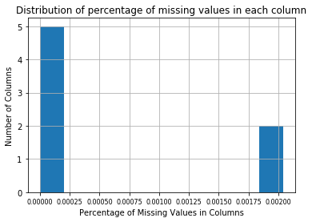

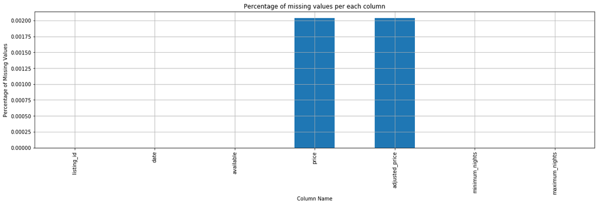

```
 There are not columns that have more than 20% Missing Values
```

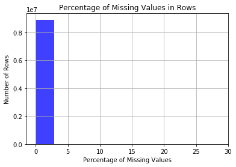

```
List of Categorical for calendar  dataset :
```

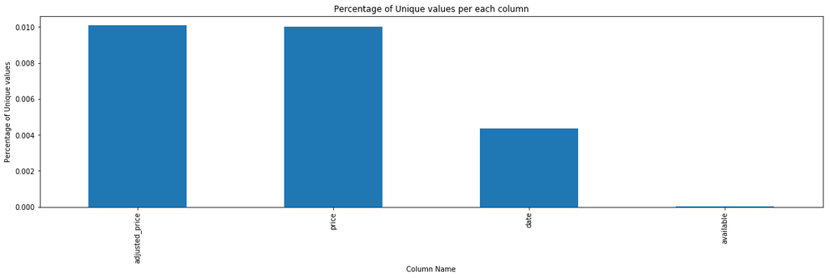

```
-  available : 2  and list of unique values that are less than 10 :  ['t' 'f']
```

```python
assesing_df(calendar)
```

#### Findings

Based on the result mentioned above for the calendar dataset, the price column's type is object which could convert to be as numeric. The missing values of columns/rows is very low.

```
Size of listings :
number of rows:  24422
number of columns:  106
                  id                            listing_url     scrape_id  \
count   2.442200e+04                                  24422  2.442200e+04
unique           NaN                                  24422           NaN
top              NaN  https://www.airbnb.com/rooms/27693673           NaN
freq             NaN                                      1           NaN
mean    1.967378e+07                                    NaN  2.019092e+13
std     1.110612e+07                                    NaN  3.707107e+00
min     1.944000e+03                                    NaN  2.019092e+13
25%     9.922960e+06                                    NaN  2.019092e+13
50%     2.010907e+07                                    NaN  2.019092e+13
75%     2.907823e+07                                    NaN  2.019092e+13
max     3.873117e+07                                    NaN  2.019092e+13

       last_scraped                            name  \
count         24422                           24371
unique            2                           23722
top      2019-09-19  Gemütliches Zimmer in Neukölln
freq          24421                               8
mean            NaN                             NaN
std             NaN                             NaN
min             NaN                             NaN
25%             NaN                             NaN
50%             NaN                             NaN
75%             NaN                             NaN
max             NaN                             NaN

                                                  summary  \
count                                               23231
unique                                              22480
top     with en-suite bathroom, TV, WIFI, bed linen, a...
freq                                                   15
mean                                                  NaN
std                                                   NaN
min                                                   NaN
25%                                                   NaN
50%                                                   NaN
75%                                                   NaN
```

[output cut: 105 more lines]

```

        calculated_host_listings_count_shared_rooms  reviews_per_month
count                                  24422.000000       20286.000000
unique                                          NaN                NaN
top                                             NaN                NaN
freq                                            NaN                NaN
mean                                       0.135083           1.123973
std                                        2.125533           1.554836
min                                        0.000000           0.010000
25%                                        0.000000           0.150000
50%                                        0.000000           0.510000
75%                                        0.000000           1.480000
max                                       43.000000          39.510000

[11 rows x 106 columns]
```

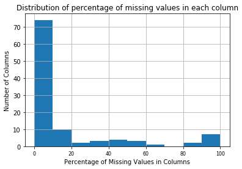

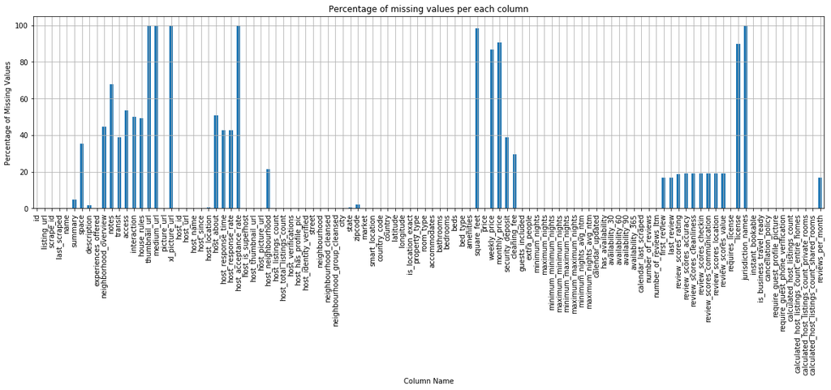

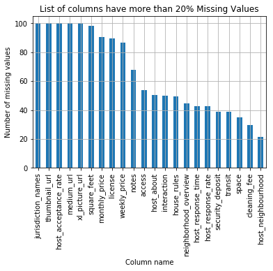

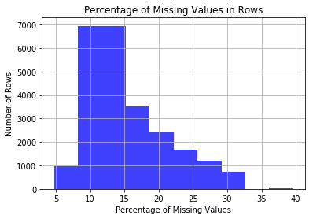

```
List of Categorical for listings  dataset :
```

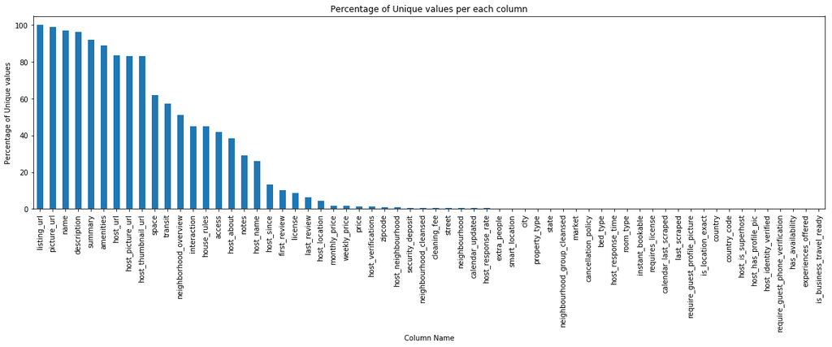

```
-  last_scraped : 2  and list of unique values that are less than 10 :  ['2019-09-19' '2019-10-11']
-  experiences_offered : 1  and list of unique values that are less than 10 :  ['none']
-  host_response_time : 4  and list of unique values that are less than 10 :  ['a few days or more' 'within an hour' 'within a few hours' 'within a day'
 nan]
-  host_is_superhost : 2  and list of unique values that are less than 10 :  ['f' 't' nan]
-  host_has_profile_pic : 2  and list of unique values that are less than 10 :  ['t' 'f' nan]
-  host_identity_verified : 2  and list of unique values that are less than 10 :  ['t' 'f' nan]
-  market : 7  and list of unique values that are less than 10 :  ['Berlin' 'Leipzig' 'Other (International)' 'New York' nan 'Juarez'
 'Potsdam' 'East Brandenburg']
-  country_code : 2  and list of unique values that are less than 10 :  ['DE' 'US']
-  country : 2  and list of unique values that are less than 10 :  ['Germany' 'United States']
-  is_location_exact : 2  and list of unique values that are less than 10 :  ['t' 'f']
-  room_type : 4  and list of unique values that are less than 10 :  ['Private room' 'Entire home/apt' 'Hotel room' 'Shared room']
-  bed_type : 5  and list of unique values that are less than 10 :  ['Real Bed' 'Pull-out Sofa' 'Futon' 'Couch' 'Airbed']
-  has_availability : 1  and list of unique values that are less than 10 :  ['t']
-  calendar_last_scraped : 2  and list of unique values that are less than 10 :  ['2019-09-19' '2019-10-11']
-  requires_license : 2  and list of unique values that are less than 10 :  ['t' 'f']
-  instant_bookable : 2  and list of unique values that are less than 10 :  ['f' 't']
-  is_business_travel_ready : 1  and list of unique values that are less than 10 :  ['f']
-  cancellation_policy : 6  and list of unique values that are less than 10 :  ['moderate' 'strict_14_with_grace_period' 'flexible' 'super_strict_60'
 'super_strict_30' 'strict' nan]
-  require_guest_profile_picture : 2  and list of unique values that are less than 10 :  ['f' 't']
-  require_guest_phone_verification : 2  and list of unique values that are less than 10 :  ['f' 't']
```

```python
assesing_df(listings)
```

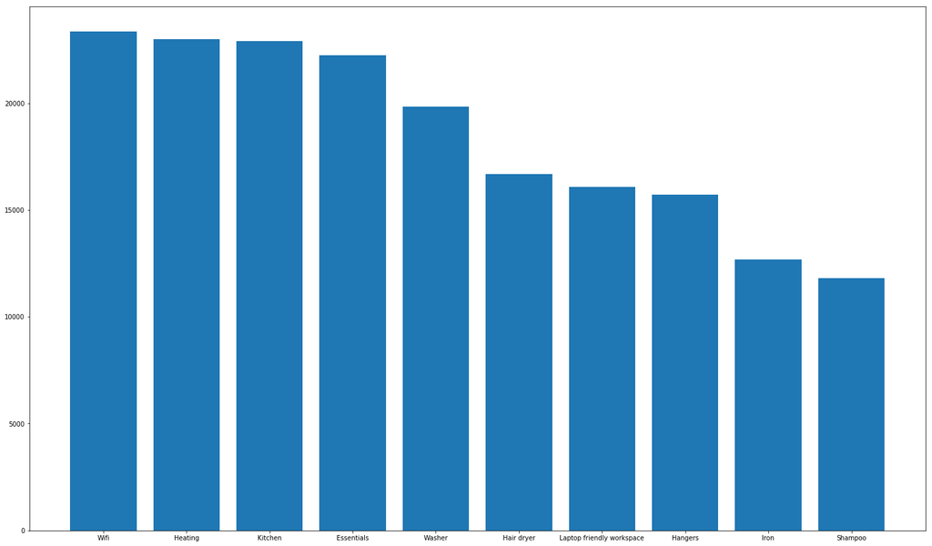

```python
# Handle amenities - Explore most common amenities
amenities = []
for index, row in listings.iterrows():
    row['amenities'] = row['amenities'].replace('{','')
    row['amenities'] = row['amenities'].replace('}','')
    row['amenities'] = row['amenities'].replace('"','')
    mylist = row['amenities'].split(',')
    for l in mylist:
        amenities.append(l)

amenities_count = Counter(amenities)
amenities_count.most_common()
x,y = zip(*amenities_count.most_common()[:10])
plt.figure(figsize=(25,15))
plt.bar( x,y)
plt.show()
```

#### Findings

Based on the result mentioned above for listings dataset,it seems like there will be data prep and cleansing required to use this dataset for business questions. We should convert the price variables to numeric and drop the unnecessary variables and convert some nessoray columns to boolean variable. The experiences offered are None for all rows. The host_location column can use some standardization if we are to use it for analysis. For example: "Berlin / Müggelsdorf", "Berlin, Deutschland" and "Neukölln, Berlin, Germany" should be considered as the same.

This amenities column contains a list of values in each row. In order to handle the amenities column, we will try to understand which are some of the most common amenities that are present within the listings. Once we know which amenities are important, we will create additional columns to represent each amenity as a boolean field.

```
Size of reviews :
number of rows:  501002
number of columns:  6
          listing_id            id        date   reviewer_id reviewer_name  \
count   5.010020e+05  5.010020e+05      501002  5.010020e+05        501002
unique           NaN           NaN        3141           NaN         61625
top              NaN           NaN  2019-06-02           NaN       Michael
freq             NaN           NaN        1283           NaN          3340
mean    1.291820e+07  2.638157e+08         NaN  7.507297e+07           NaN
std     1.002893e+07  1.558552e+08         NaN  7.211280e+07           NaN
min     1.944000e+03  4.283000e+03         NaN  3.190000e+02           NaN
25%     3.485841e+06  1.306522e+08         NaN  1.706364e+07           NaN
50%     1.189906e+07  2.619161e+08         NaN  4.764211e+07           NaN
75%     2.044847e+07  4.132042e+08         NaN  1.186202e+08           NaN
max     3.872391e+07  5.322665e+08         NaN  2.960384e+08           NaN

                                                 comments
count                                              500760
unique                                             484409
top     The host canceled this reservation 2 days befo...
freq                                                  571
mean                                                  NaN
std                                                   NaN
min                                                   NaN
25%                                                   NaN
50%                                                   NaN
75%                                                   NaN
max                                                   NaN
```

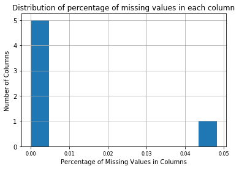

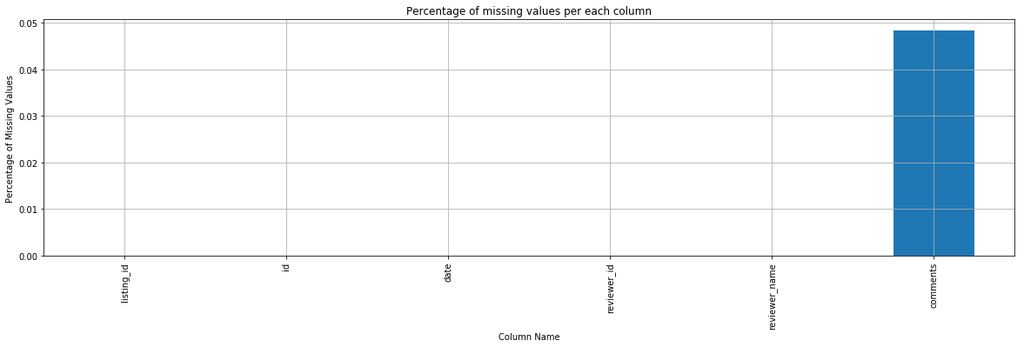

```
 There are not columns that have more than 20% Missing Values
```

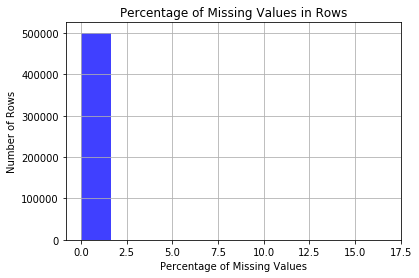

```
List of Categorical for reviews  dataset :
```

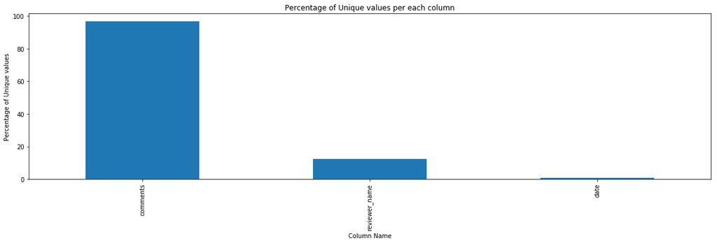

```python
assesing_df(reviews)
```

### 2.3 Cleaning Data

```python
#Remove Dollar
def remove_dollar(column_name, df):
    df[column_name] = df[column_name].str.replace('$','').str.replace(',','')
    df[column_name].fillna(0, inplace=True)
```

```python
#Remove Numeric
def make_numeric(column_name, df):
    df[column_name] = pd.to_numeric(df[column_name])
```

```python
def make_boolean(column_name, df):
    df[column_name] = df[column_name] == 't'
```

```python
def make_datetype(column_name, df):
    df[column_name] = pd.to_datetime(df[column_name])
```

```python
# remove dollar and make column type as numeric in Calendar and listings datasets
remove_dollar('price', calendar)
make_numeric('price', calendar)
remove_dollar('adjusted_price', calendar)
make_numeric('adjusted_price', calendar)
remove_dollar('price', listings)
make_numeric('price', listings)
```

```python
# make date column as date type and available column as boolean type for listings dataset
make_datetype('date', calendar)
make_boolean('available', calendar)
```

# 3. Business Understanding:

### 3.1 How does pricing by season and what is the high season in Berlin?

```python
def price_analysis_monthly(df):
    # Plot the average price by month/year
    df['year'] = pd.DatetimeIndex(df['date']).year
    df['month'] = pd.DatetimeIndex(df['date']).month
    mean_price_monthly = df.groupby(['year','month'],sort=False)['price'].mean()
    plt.rcParams.update({'font.size': 18})
    mean_price_monthly.plot(kind = 'barh' , figsize = (30,10));
    plt.show()
```

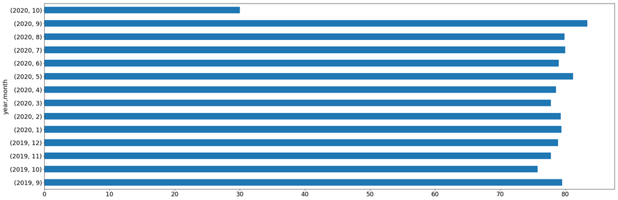

```python
price_analysis_monthly(calendar)
```

#### Findings

The graph above shows us how the mean prices change over the year. We have noticed that September and May are the peak months. Since the weather during these months in Berlin is always good, it makes sense that prices in these months are higher compared to others.

### 3.2 How does pricing by neighborhood and what is the most expensive place in Berlin?

```python
def price_analysis_neighbourhood_count(df):
    listings.groupby(['neighbourhood_cleansed'])[['price']].mean().plot(figsize=(30,10))
    plt.show()
    neighbourhood_count = pd.DataFrame()
    neighbourhood_count['count'] = listings['neighbourhood_cleansed'].value_counts()
    neighbourhood_mean = pd.DataFrame()
    neighbourhood_mean['mean_price'] = listings.groupby(listings['neighbourhood_cleansed'])['price'].mean()
    neighbourhood_info = pd.merge(neighbourhood_mean, neighbourhood_count, left_on = neighbourhood_mean.index,right_on = neighbourhood_count.index)
    neighbourhood_info.index = neighbourhood_info.key_0
    plt.rcParams.update({'font.size': 12})
    neighbourhood_info.sort_values(by = 'mean_price', ascending=False).head(5).plot(kind = 'barh',figsize = (15,10))
    plt.show()
    plt.rcParams.update({'font.size': 12})
    neighbourhood_info.sort_values(by = 'mean_price', ascending=False).tail(5).plot(kind = 'barh',figsize = (15,10))
    plt.show()
```

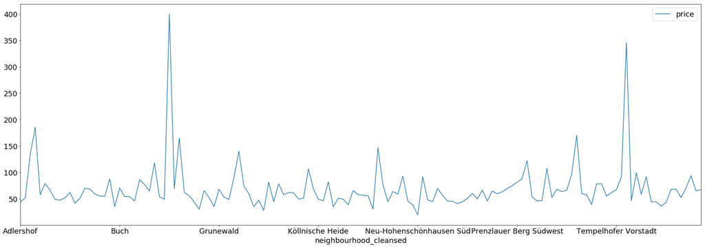

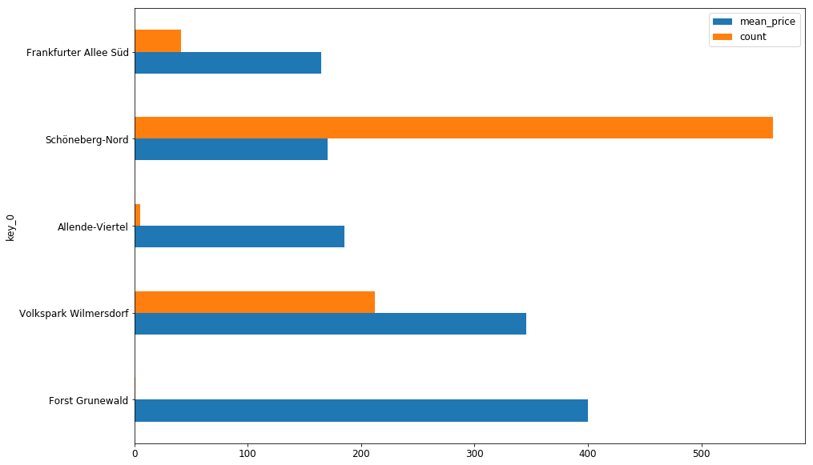

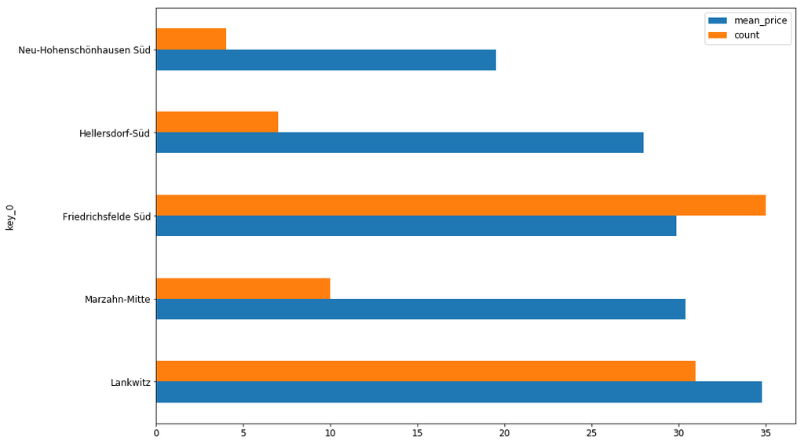

```python
price_analysis_neighbourhood_count(listings)
```

#### Findings

From the charts above, we have noticed that the neighbourhoods of Forst Grunewald, Volkspark Wilmersdorf and Allende-Viertel have highest mean price with 200 dollar and 400 dollar , while the neighbourhoods of Neu-Hohenschönhausen, Hellersdorf-süd have lowest mean prices with around $ 25.

Similarily we see that the neighbourhoods of Alexanderplatz and Schöneberg-Nord have highest listing counts, while neighbourhoods of Forst-Grunewald and Neu-Hohenschönhausen have lower listing counts

### 3.3 Is it possile to make an accurate predictive model for listing price based on machine leraning

###### Cleansing dataset for predictive model

Based on assesing charts above for listings data we decided to clean as following:

- Drop columns that have less impact, For example: 'id','listing_url','scrape_id','last_scraped','thumbnail_url','medium_url','xl_picture_url','host_id','host_url', 'host_thumbnail_url','host_verifications','street','neighbourhood','neighbourhood_group_cleansed','zipcode','smart_location', 'country','latitude','longitude','weekly_price','monthly_price','calendar_updated','calendar_last_scraped','first_review', 'last_review','calculated_host_listings_count','reviews_per_month','jurisdiction_names', 'host_acceptance_rate', 'name','summary','space','description','experiences_offered','neighborhood_overview','notes','transit','access','house_rules', 'picture_url','market','host_response_time','state','license','host_name', 'host_location', 'host_about', 'host_picture_url','interaction','require_guest_profile_picture' , 'require_guest_phone_verification' , 'host_since' and 'host_neighbourhood'.
- Set 0 for bathroom where bathroom is Nan.
- Set 1 for bedrooms where bedrooms is Nan.
- Set 1 for beds where beds is Nan.
- Set all review scores columns with 0 for Nan values.
- Set host_listings_count and host_total_listings_count to 1.
- Set host_response_rate to 0 for Nan values and convert to numric
- Clean security_deposit, cleaning_fee and extra people.
- Clean up city name.
- Drop record with empty value for cancellation_policy and host_since.
- we take only those amenities that are present more than 11000 times , which are below. ('Wifi', 23347), ('Heating', 22990), ('Kitchen', 22904), ('Essentials', 22242), ('Washer', 19834), ('Hair dryer', 16680), ('Laptop friendly workspace', 16072), ('Hangers', 15714), ('Iron', 12682), ('Shampoo', 11814), ('Hot water', 11394), ('TV', 11068)

```python
def handle_amenities(df_list):
    # Handle amenities - Explore most common amenities
    amenities = []
    for index, row in df_list.iterrows():
        row['amenities'] = row['amenities'].replace('{','')
        row['amenities'] = row['amenities'].replace('}','')
        row['amenities'] = row['amenities'].replace('"','')
        mylist = row['amenities'].split(',')
        for l in mylist:
            amenities.append(l)

    amenities_count = Counter(amenities)
    amenities_count.most_common()
    amenities_new_cols =['amenities_wifi|Wifi',
     'amenities_heating|Heating',
     'amenities_kitchen|Kitchen',
     'amenities_essentials|Essentials',
     'amenities_washer|Washer',
     'amenities_hair_dryer|Hair dryer',
     'amenities_laptop_friendly_workspace|Laptop friendly workspace',
     'amenities_hangers|Hangers',
     'amenities_iron|Iron',
     'amenities_shampoo|Shampoo',
     'amenities_hot_water|Hot water',
     'amenities_TV|TV']
    for c in amenities_new_cols:
        c_colname,c_desc = c.split('|')
        df_list[c_colname] = df_list['amenities'].apply(lambda x: 1 if c_desc in x else 0)
    # Drop the original amenities field
    df_list = df_list.drop('amenities', axis = 1)
    return df_list
```

```python
def set_bool_tf(tfdata):
    if tfdata == 't':
        return 1
    else:
        return 0
```

```python
def cleaning_for_predictions(listings):
    df_list = listings.copy()
    cols_less_impact = ['id','listing_url','scrape_id','last_scraped','thumbnail_url','medium_url','xl_picture_url','host_id',
                        'host_url','host_thumbnail_url','host_verifications','street','neighbourhood',
                        'neighbourhood_group_cleansed','zipcode','smart_location','country','latitude','longitude',
                        'weekly_price','monthly_price','calendar_updated','calendar_last_scraped','first_review','last_review',
                        'calculated_host_listings_count','reviews_per_month','jurisdiction_names',
                        'host_acceptance_rate','square_feet']
    df_list = df_list.drop(cols_less_impact, axis=1)
    col_isnull = df_list.columns[df_list.isnull().all()].tolist()
    df_list = df_list.drop(col_isnull, axis=1)
    # Set 0 for bathroom where bathroom is Nan
    df_list['bathrooms'] = df_list['bathrooms'].fillna(0)
    # Set 1 for bedrooms where bedrooms is Nan
    df_list['bedrooms'] = df_list['bedrooms'].fillna(1)
    # Set 1 for beds where beds is Nan
    df_list['beds'] = df_list['beds'].fillna(1)
    # Set all review scores columns with 0 for Nan values
    cols_fillna_0 = ['review_scores_rating','review_scores_accuracy','review_scores_cleanliness','review_scores_checkin','review_scores_communication','review_scores_location','review_scores_value']
    for col in cols_fillna_0:
        df_list[col] = df_list[col].fillna(0)
    # Set host_listings_count and host_total_listings_count to 1
    df_list['host_listings_count'] = df_list['host_listings_count'].fillna(1)
    df_list['host_total_listings_count'] = df_list['host_total_listings_count'].fillna(1)
    tf_fields = ['host_is_superhost','host_has_profile_pic','host_identity_verified','is_location_exact','has_availability','requires_license',
                'instant_bookable','is_business_travel_ready']
    for t in tf_fields:
        df_list[t] = df_list[t].apply(set_bool_tf)
    drop_list = ['name','summary','space','description','experiences_offered','neighborhood_overview','notes','transit','access','house_rules','picture_url','market','host_response_time','state','license','host_name', 'host_location', 'host_about', 'host_picture_url','interaction','require_guest_profile_picture', 'require_guest_phone_verification']
    df_list = df_list.drop(drop_list, axis = 1)

    df_list['host_response_rate'] = df_list['host_response_rate'].apply(lambda x: 0 if x == 'N/A' else x)
    df_list['host_response_rate'] = df_list['host_response_rate'].replace('[\%,]', '', regex=True).astype(float)
    df_list['host_response_rate'] = df_list['host_response_rate'].fillna(0)

    #df_list['host_neighbourhood'] = df_list['host_neighbourhood'].fillna('N/A')

    # Clean security_deposit, cleaning_fee and extra people
    df_list['security_deposit'] = df_list['security_deposit'].replace('[\$,]', '', regex=True).astype(float)
    df_list['cleaning_fee'] = df_list['cleaning_fee'].replace('[\$,]', '', regex=True).astype(float)
    df_list['extra_people'] = df_list['extra_people'].replace('[\$,]', '', regex=True).astype(float)
    df_list['security_deposit'] = df_list['security_deposit'].fillna(0)
    df_list['cleaning_fee'] = df_list['cleaning_fee'].fillna(0)
    # Clean up city names
    df_list['city'] = df_list['city'].fillna('berlin')
    df_list['city'] = df_list['city'].str.lower()
    df_list['city'] = df_list['city'].str.strip()
    # Drop record with empty value for cancellation_policy and host_since.
    df_list = df_list.dropna(subset=['cancellation_policy','host_since'], axis=0)
    make_datetype('host_since',listings)
    df_list['host_since_year'] = pd.DatetimeIndex(df_list['host_since']).year
    df_list['host_since_year_month'] = pd.DatetimeIndex(df_list['host_since']).month
    df_list = df_list.drop(['host_since','host_neighbourhood'], axis = 1)
    df_list = handle_amenities(df_list)
    return df_list
```

```python
df_list = cleaning_for_predictions(listings)
```

## Model Data

```python
# Get Dummies for categorical fields

cat_fields = df_list.select_dtypes(include=['object']).columns

df_list = pd.get_dummies(df_list, columns=cat_fields)
df_list.head()
df_list.shape
```

```
(24389, 307)
```

```python
# Build out X and y, y to be price column and X to be all the other columns
y = df_list['price']
X = df_list.drop(['price'], axis=1)
```

```python
# Create train and test data sets
X_train, X_test, y_train, y_test = train_test_split(X, y, test_size = .30, random_state=40)

print(X_train.shape, y_train.shape)
print(X_test.shape, y_test.shape)
```

```
(17072, 306) (17072,)
(7317, 306) (7317,)
```

```python
def coef_weights(coefficients, X_train):
    '''
    Function to get coefficients back for each of the features
    INPUT:
    coefficients - the coefficients of the linear model
    X_train - the training data, so the column names can be used
    OUTPUT:
    coefs_df - a dataframe holding the coefficient, estimate, and abs(estimate)

    Provides a dataframe that can be used to understand the most influential coefficients
    in a linear model by providing the coefficient estimates along with the name of the
    variable attached to the coefficient.
    '''
    coefs_df = pd.DataFrame()
    coefs_df['est_int'] = X_train.columns
    coefs_df['coefs'] = coefficients.feature_importances_
    coefs_df['abs_coefs'] = np.abs(coefficients.feature_importances_)
    coefs_df = coefs_df.sort_values('abs_coefs', ascending=False)
    return coefs_df
```

```python
ForestRegressor = RandomForestRegressor(n_estimators=500)
ForestRegressor.fit(X_train, y_train)
```

```
RandomForestRegressor(bootstrap=True, criterion='mse', max_depth=None,
           max_features='auto', max_leaf_nodes=None,
           min_impurity_decrease=0.0, min_impurity_split=None,
           min_samples_leaf=1, min_samples_split=2,
           min_weight_fraction_leaf=0.0, n_estimators=500, n_jobs=None,
           oob_score=False, random_state=None, verbose=0, warm_start=False)
```

```python
y_train_preds = ForestRegressor.predict(X_train)
y_test_preds = ForestRegressor.predict(X_test)
train_score = r2_score(y_train, y_train_preds)
test_score = r2_score(y_test,y_test_preds)
median_absolute_error_train = median_absolute_error(y_train, y_train_preds)
median_absolute_error_test = median_absolute_error(y_test, y_test_preds)
print("The rsquared score on the training data was {}.  The rsquared score on the test data was {}.\n and absolute median error of {} in our model which is not very accurate.".format(train_score, test_score,median_absolute_error_test))
```

```
The rsquared score on the training data was 0.9714870932730119.  The rsquared score on the test data was 0.7404254275559872.
 and absolute median error of 11.468000000000004 in our model which is not very accurate.
```

```python
coef_df = coef_weights(ForestRegressor, X_train)
coef_df.head(10)
```

|  | est_int | coefs | abs_coefs |
| --- | --- | --- | --- |
| 244 | city_schöneberg | 0.295383 | 0.295383 |
| 179 | neighbourhood_cleansed_Volkspark Wilmersdorf | 0.107100 | 0.107100 |
| 292 | room_type_Hotel room | 0.047913 | 0.047913 |
| 263 | property_type_Boutique hotel | 0.045760 | 0.045760 |
| 301 | cancellation_policy_moderate | 0.042322 | 0.042322 |
| 44 | host_since_year_month | 0.040713 | 0.040713 |
| 59 | neighbourhood_cleansed_Alexanderplatz | 0.035616 | 0.035616 |
| 0 | host_response_rate | 0.027573 | 0.027573 |
| 276 | property_type_Hotel | 0.026353 | 0.026353 |
| 21 | minimum_nights_avg_ntm | 0.020579 | 0.020579 |

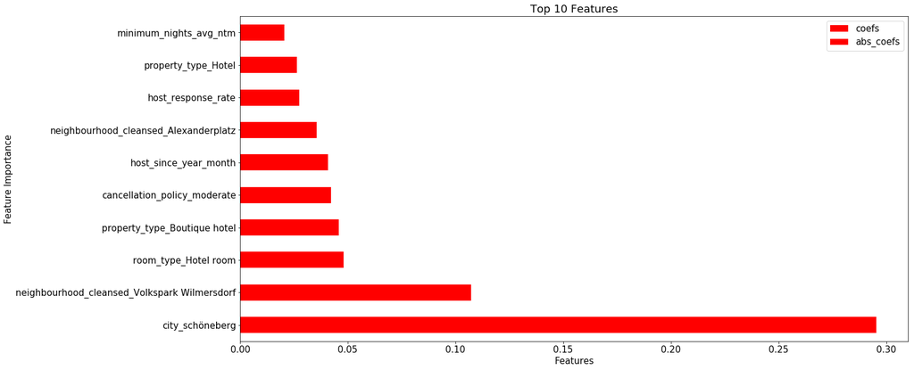

```python
coef_df.index = coef_df.est_int
plt.rcParams.update({'font.size': 15})
coef_df.sort_values('coefs', ascending=False).head(10).plot(kind = 'barh',figsize = (20,10), facecolor='red')
plt.xlabel('Features')
plt.ylabel('Feature Importance')
plt.title('Top 10 Features')
plt.show()
```